# R 중급 통계분석 3일차 (5)

## ggplot 기본함수

data 생성 후 시각화하는 예제

### barplot example

```r
months <-rep(c("jan", "feb", "mar", "apr", "may", "jun",
               "jul", "aug", "sep", "oct", "nov", "dec"), 2)
chickens <-c(1, 2, 3, 3, 3, 4, 5, 4, 3, 4, 2, 2)
eggs <-c(0, 8, 10, 13, 16, 20, 25, 20, 18, 16, 10, 8)
values <-c(chickens, eggs)
type <-c(rep("chickens", 12), rep("eggs", 12))
mydata <-data.frame(months, values, type)
head(mydata)
```

```
##   months values     type
## 1    jan      1 chickens
## 2    feb      2 chickens
## 3    mar      3 chickens
## 4    apr      3 chickens
## 5    may      3 chickens
## 6    jun      4 chickens
```

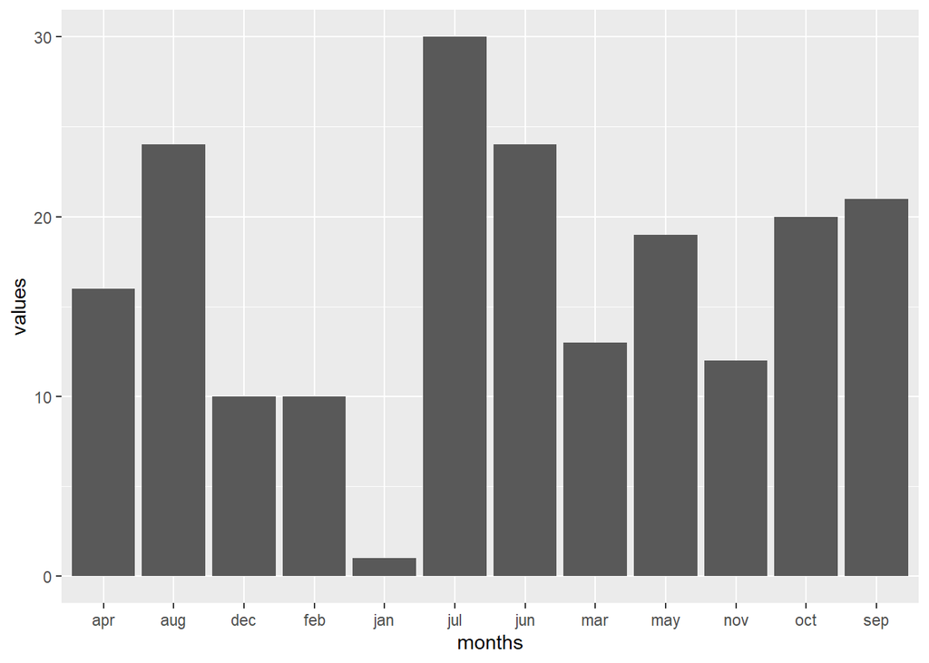

```r
library(ggplot2)
# p <-ggplot(mydata, aes(months, values))
# p +geom_bar()

p <-ggplot(mydata, aes(months, values))
p +geom_bar(stat="identity")
```

위의 그림을 보면 달이 원하는 순서대로 되어 있지 않는다.

즉, ggplot2에서는 x축을 자동으로 알파벳 순서로 정렬하여 시각화 한다.

내가 원하는 순서대로 처리할려면? `factor` 처리를 해야한다.

`factor`처리시 내가 원하는 순서대로 `levels`를 설정하자.

```r
mydata$months <-factor(mydata$months,
                      levels = c("jan", "feb", "mar", "apr", "may", "jun", "jul", "aug", "sep", "oct", "nov", "dec"))
```

이제 ggplot으로 그림을 그려보자.

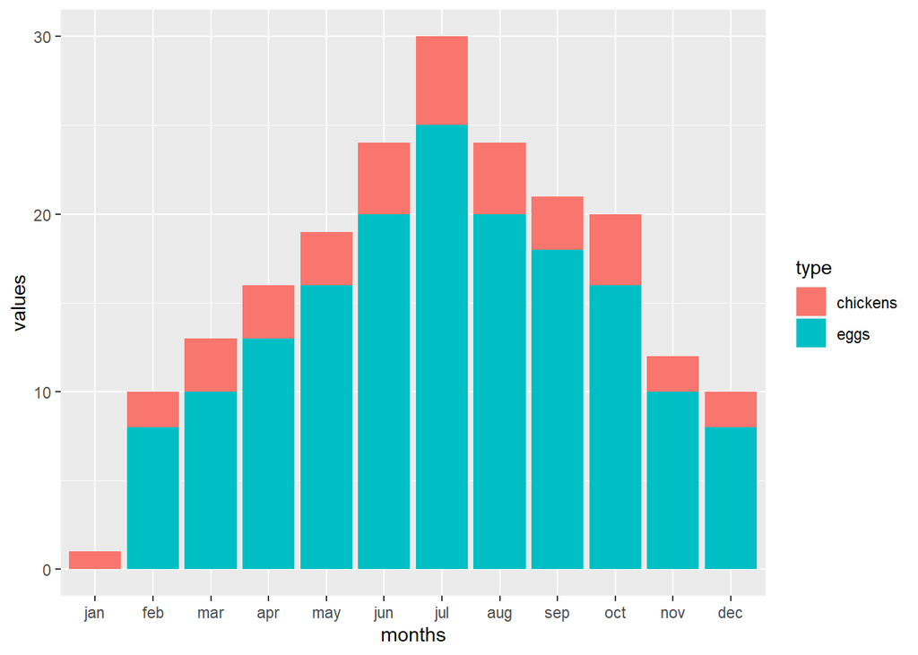

```r
p <-ggplot(mydata, aes(months, values))
p +geom_bar(stat = "identity", aes(fill = type))
```

그림을 그릴때 plot의 beside옵션을 주기 위해선?

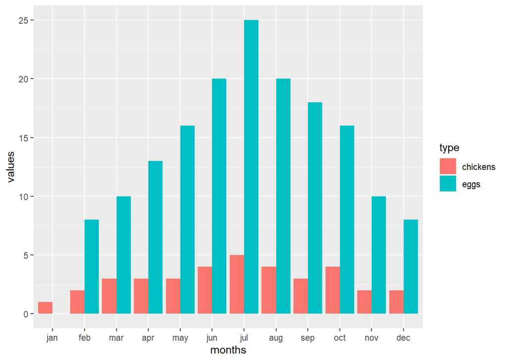

```r
p <-ggplot(mydata, aes(months, values))
p +geom_bar(stat = "identity", aes(fill = type), position="dodge")
```

이제 그림에 text를 넣어보자. 그냥 label을 사용할 경우 구분하여 표시되지 않는다.

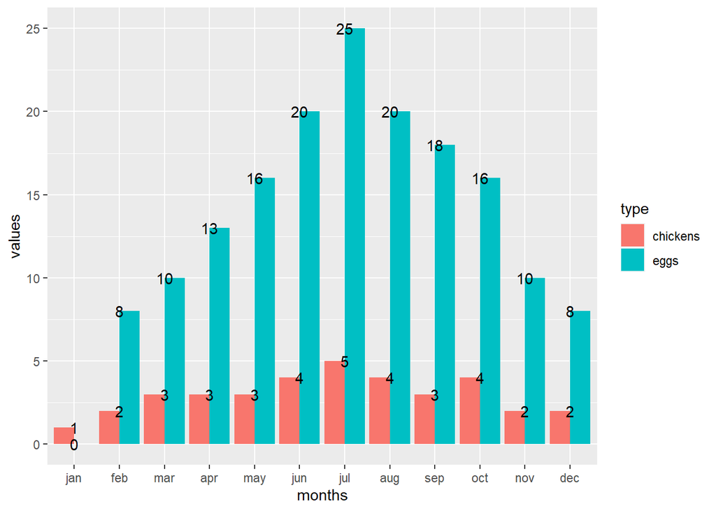

```r
ggplot(mydata, aes(months, values))+
  geom_bar(stat = "identity", aes(fill = type), position="dodge") +
  geom_text(aes(label=values))
```

geom_text를 사용시 position_dodge(width)를 사용하자. vjust를 사용하면 y축 위치를 조정할 있다.

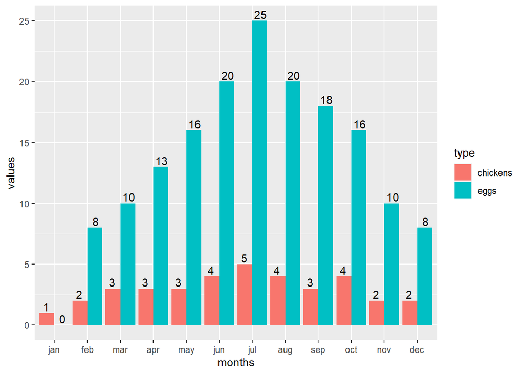

```r
ggplot(mydata, aes(x=months, y=values, fill=type))+
  geom_bar(stat = "identity",  position="dodge") +
  geom_text(aes(label=values), position=position_dodge(width=1), vjust=-0.25)
```

음수처리하면 좌우 대칭인 그림을 쉽게 그릴 수 있다.

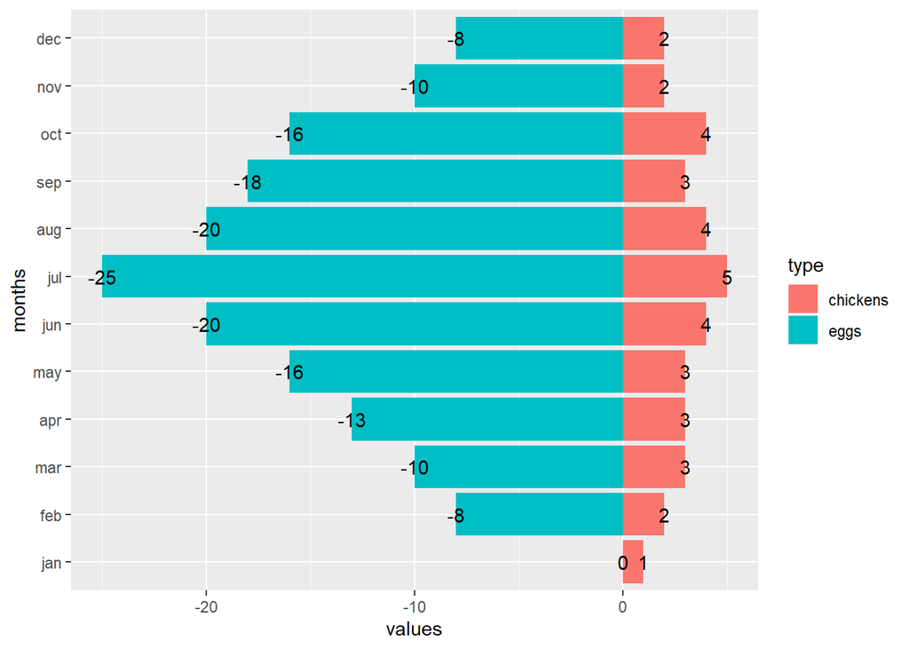

```r
values <-c(chickens, -eggs)
type <-c(rep("chickens", 12), rep("eggs", 12))
mydata <-data.frame(months, values, type)
mydata$months <-factor(mydata$months,
                      levels = c("jan", "feb", "mar", "apr", "may", "jun", "jul", "aug", "sep", "oct", "nov", "dec"))

ggplot(mydata, aes(x=months, y=values, fill=type))+
  geom_bar(stat = "identity",  position="identity") +
  geom_text(aes(label=values))+coord_flip()
```

### boxplot example

상자그림을 위한 자료를 준비해보자.

```r
data("ToothGrowth")
ToothGrowth$dose <- as.factor(ToothGrowth$dose)
head(ToothGrowth, 4)
```

```
##    len supp dose
## 1  4.2   VC  0.5
## 2 11.5   VC  0.5
## 3  7.3   VC  0.5
## 4  5.8   VC  0.5
```

기본적인 boxplot을 ggplot에서 자료를 불러온 후 geom_boxplot()을 사용하된다.

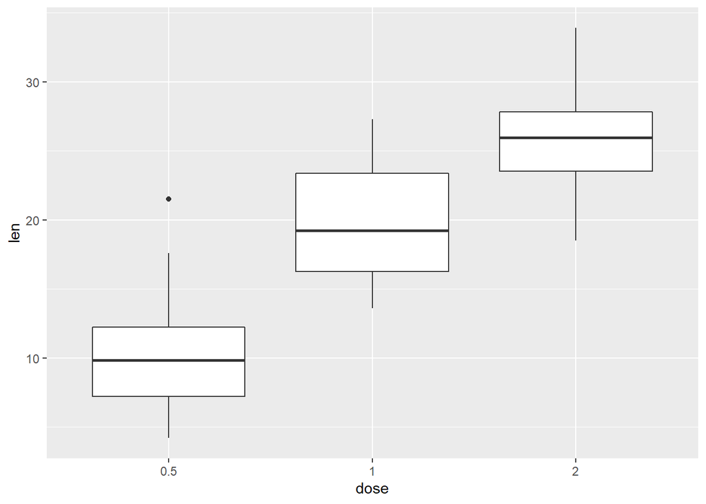

```r
e <- ggplot(ToothGrowth, aes(x = dose, y = len))
e + geom_boxplot()
```

notch를 사용하면 상자그림의 좌우대칭여부도 확인할 있다. geom_point를 통해 평균점을 `red`로 표현해보자.

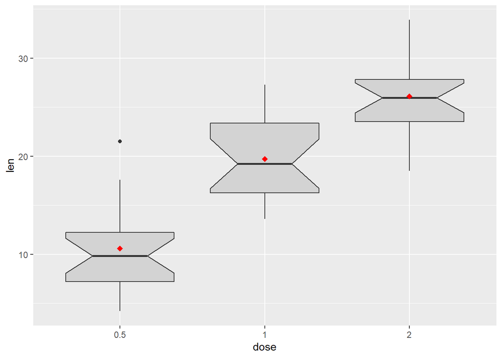

```r
e + geom_boxplot(notch = TRUE, fill = "lightgray")+
  stat_summary(fun.y = mean, geom = "point",
               shape = 18, size = 2.5, color = "red")
```

scale_x_discrete를 수정하면 원하는 순서대로 혹은 원하는 것만 선택하여 그림을 그릴 수 있다.

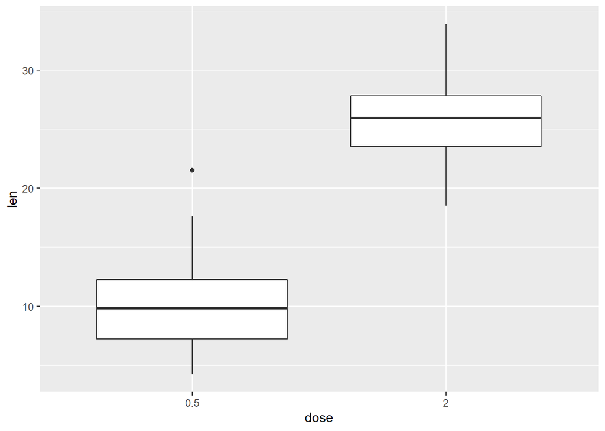

```r
e + geom_boxplot() +
  scale_x_discrete(limits=c("0.5", "2"))
```

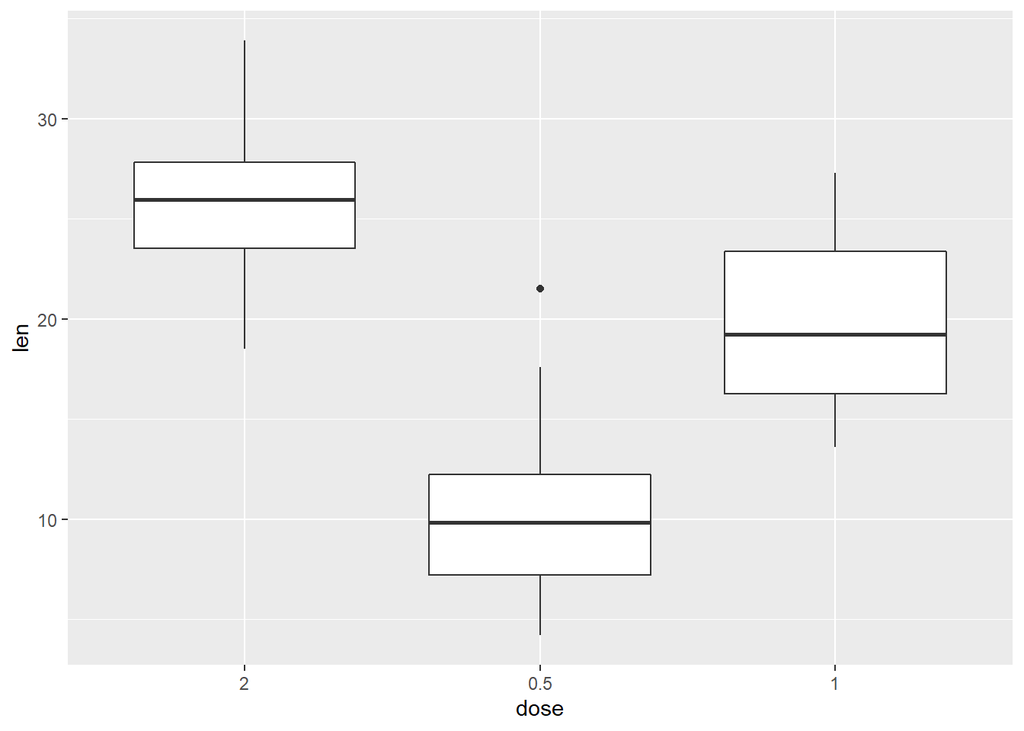

```r
e + geom_boxplot() +
  scale_x_discrete(limits=c("2", "0.5", "1"))
```

boxplot에서 color는 선의 색을 fill은 채우는 색을 결정한다.

scale_color_manual을 통해 원하는 값들을 정할 수 있다.

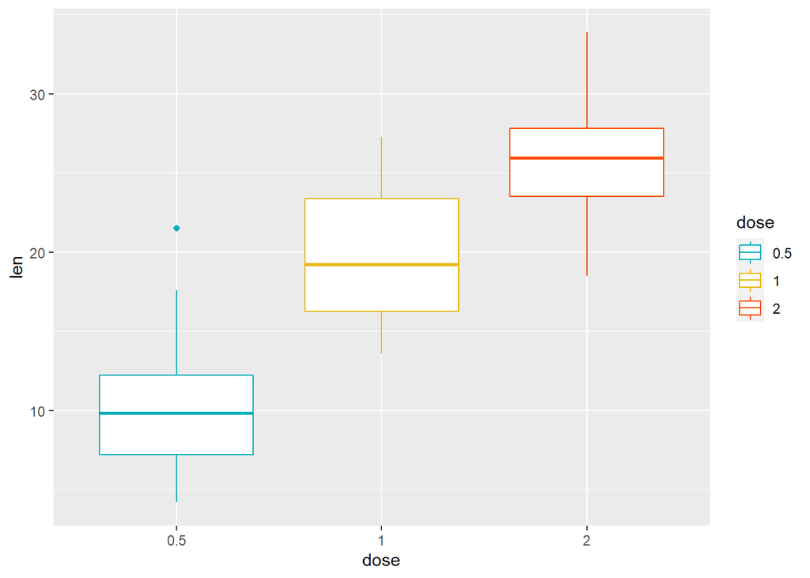

```r
e + geom_boxplot(aes(color = dose))+
  scale_color_manual(values = c("#00AFBB", "#E7B800", "#FC4E07"))
```

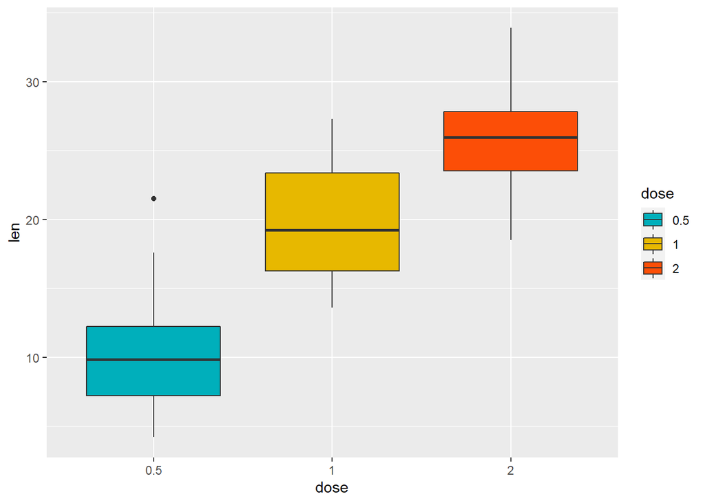

```r
e + geom_boxplot(aes(fill = dose)) +
  scale_fill_manual(values = c("#00AFBB", "#E7B800", "#FC4E07"))
```

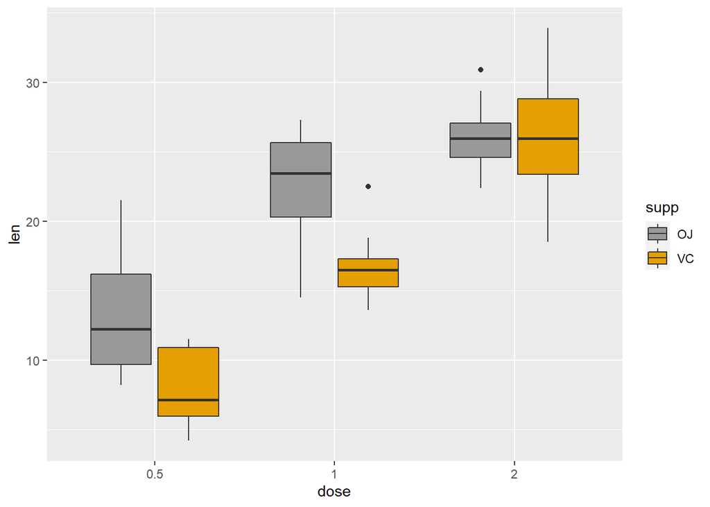

```r
e2 <- e +
  geom_boxplot(aes(fill = supp)) +
  scale_fill_manual(values = c("#999999", "#E69F00"))
e2
```

facet_+wrap을 통해 그램의 layout을 변경할 수 있다.

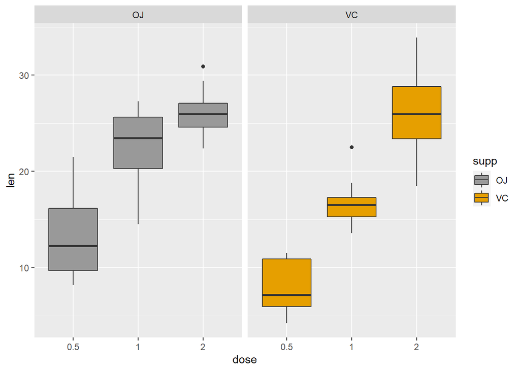

```r
e2 + facet_wrap(~supp)
```

### pie chart example

원도표는 ggplot()에서는 geom_bar()를 이용하여 그려진다.

먼저 자료를 생성해보자.

```r
count.data <- data.frame(
  class = c("1st", "2nd", "3rd", "Crew"),
  n = c(325, 285, 706, 885),
  prop = c(14.8, 12.9, 32.1, 40.2)
)
count.data
```

```
##   class   n prop
## 1   1st 325 14.8
## 2   2nd 285 12.9
## 3   3rd 706 32.1
## 4  Crew 885 40.2
```

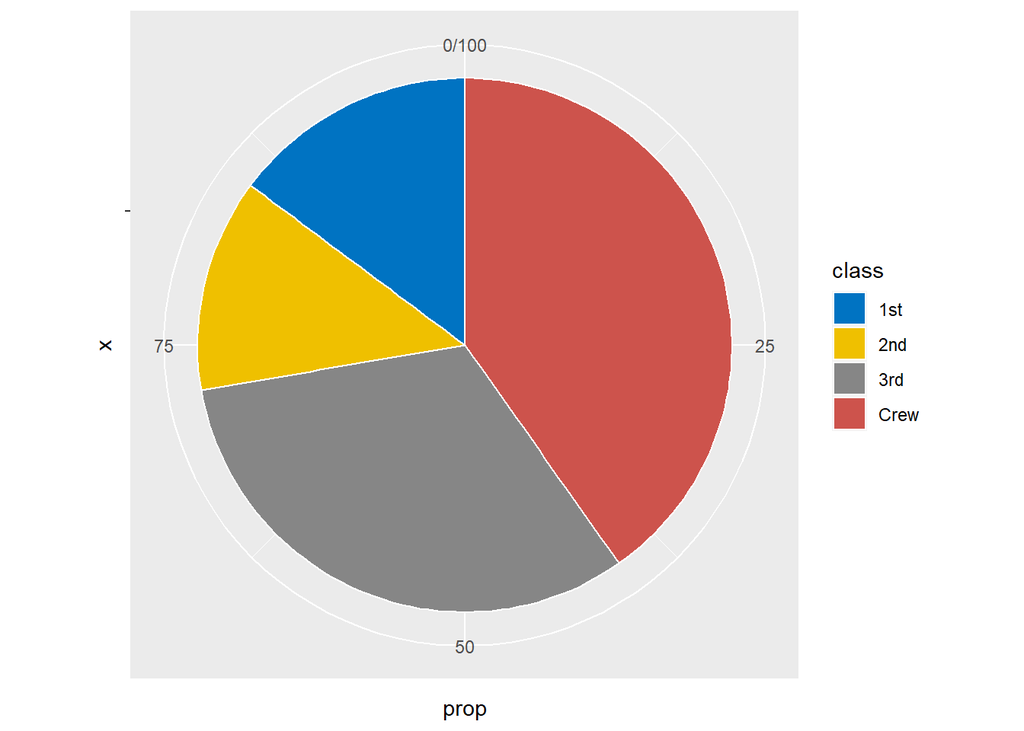

```r
mycols <- c("#0073C2FF", "#EFC000FF", "#868686FF", "#CD534CFF")

p1<- ggplot(count.data, aes(x = "", y = prop, fill = class)) +
     geom_bar(width = 1, stat = "identity", color = "white") +
     coord_polar("y", start = 0)+
     scale_fill_manual(values = mycols)
p1
```

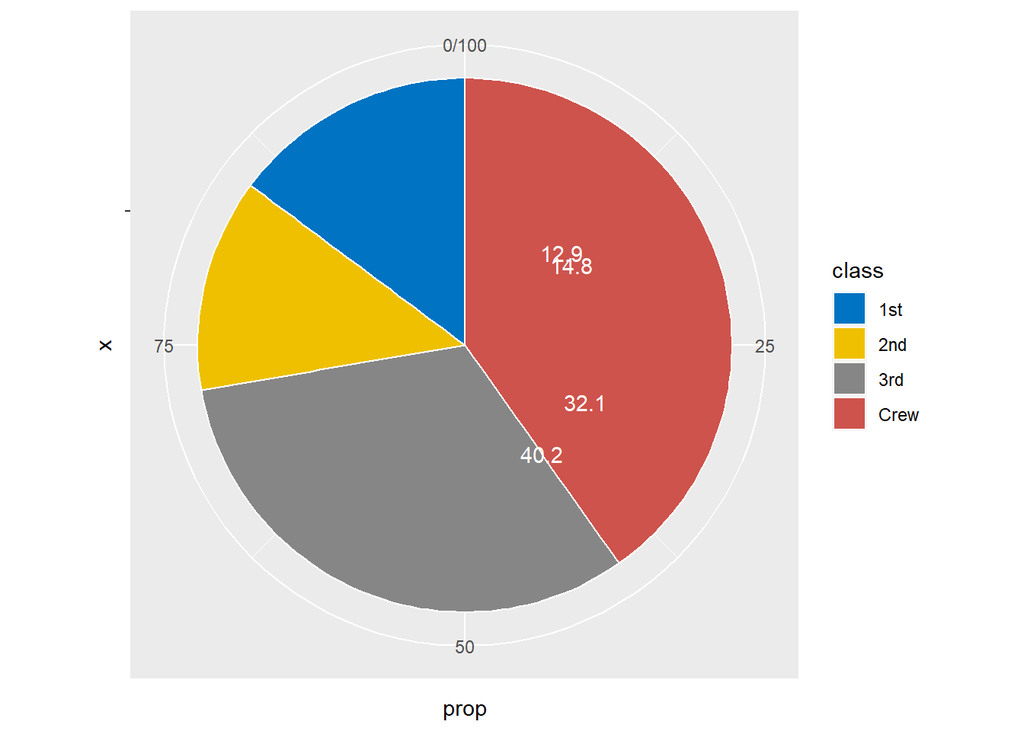

```r
p1+ geom_text(aes(label = prop), color = "white")
```

그림은 그려지지만 %의 label 위치가 일치하지 않음.

위치를 조정하기 위해선 ggplot에서 자동으로 class를 정렬시키므로 이를 고려한 count.data를 생성한다.

count.data는 변경되었으므로 geom_text에서 다시 불러주자.

```r
library(dplyr)
```

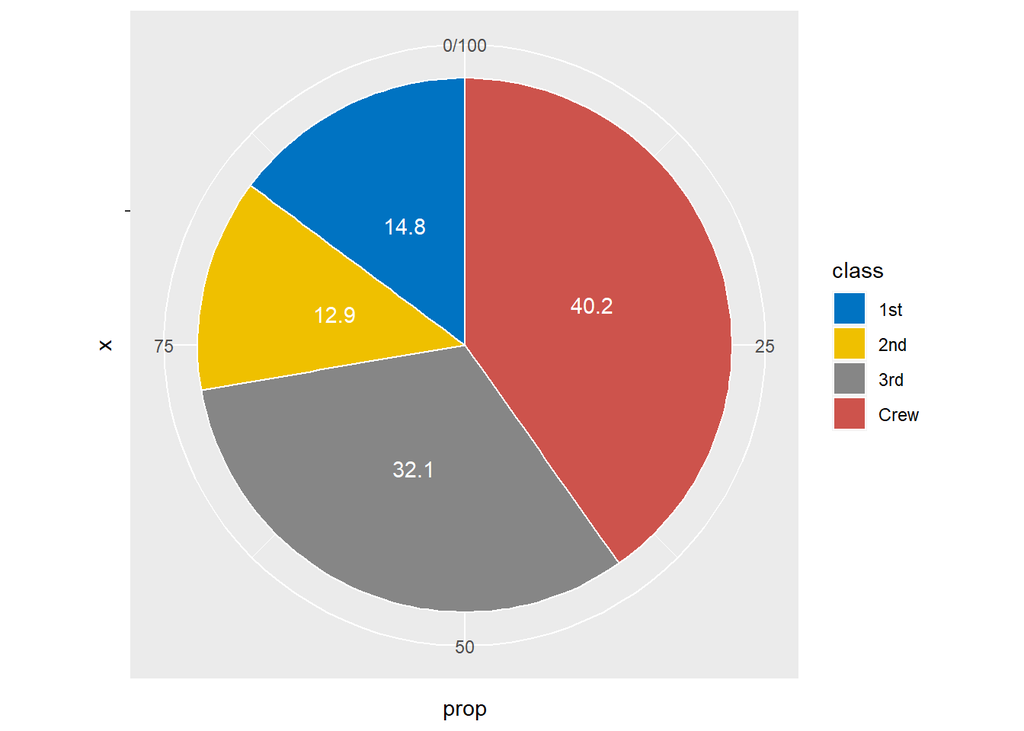

```r
count.data <- count.data %>%
  arrange(desc(class)) %>%
  mutate(lab.ypos = cumsum(prop) - 0.5*prop)

p1+ geom_text(data=count.data, aes(label = prop,y = lab.ypos), color = "white")
```

xlim()을 추가시키면 도넛차트가 생성된다.

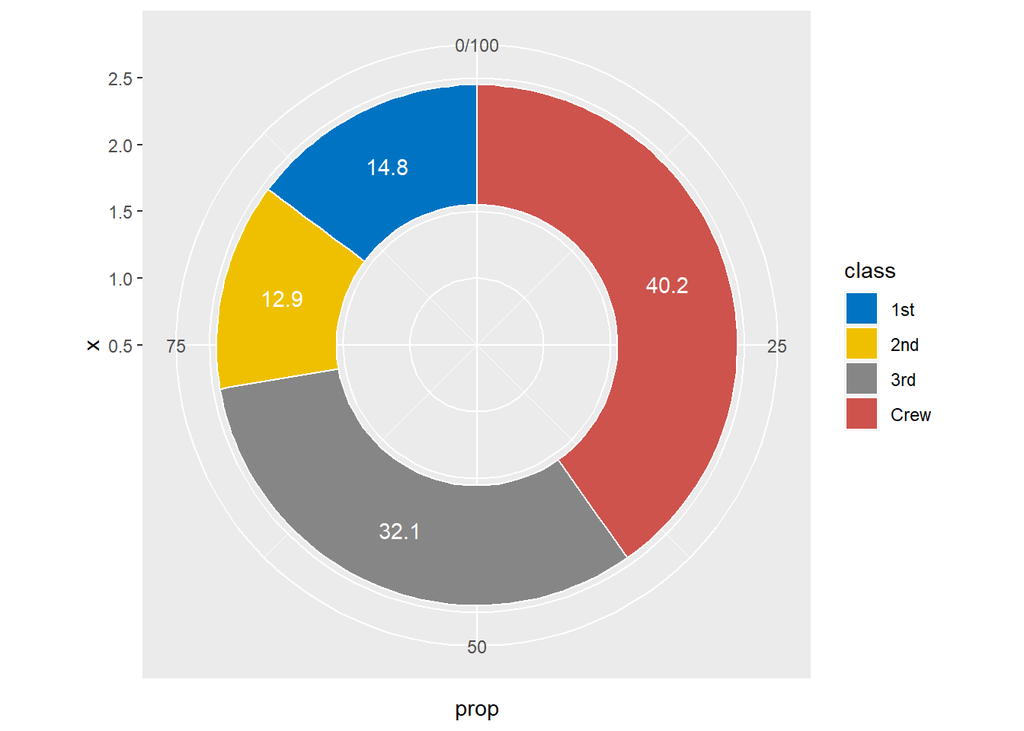

```r
ggplot(count.data, aes(x = 2, y = prop, fill = class)) +
  geom_bar(stat = "identity", color = "white") +
  coord_polar(theta = "y", start = 0)+
  geom_text(aes(y = lab.ypos, label = prop), color = "white")+
  scale_fill_manual(values = mycols) +
  xlim(0.5, 2.5)
```